# Statistic_Project_FlorentinaVaniaS

## Question 11 A computer repair service is examining the time taken on service calls to repair computers. Data are obtained for 30 service calls and are available on the Excel file CompRepair. The variables include X1 = number of machines to be repaired (NUMBER), X2 = years of experience of service person (EXPER), and Y = time taken (in minutes) to provide service (TIME). Develop a polynomial regression model to predict average time on the service calls using EXPER and NUMBER as explanatory variables. Justify your model choice including transformations of any variables.

[figure not shown]

```r
CompRepair <- read_excel("CompRepair.xlsx")
plot(CompRepair$TIME, CompRepair$NUMBER,
     main = "Average Time and Number of Machines", xlab = "NUMBER",
     ylab = "Average Time", pch=16)
abline(lm(CompRepair$TIME ~ CompRepair$NUMBER), col = "red")
lines(lowess(CompRepair$TIME, CompRepair$NUMBER), col="blue") ## lowess = Locally weighted Scatterplot Smoothing
```

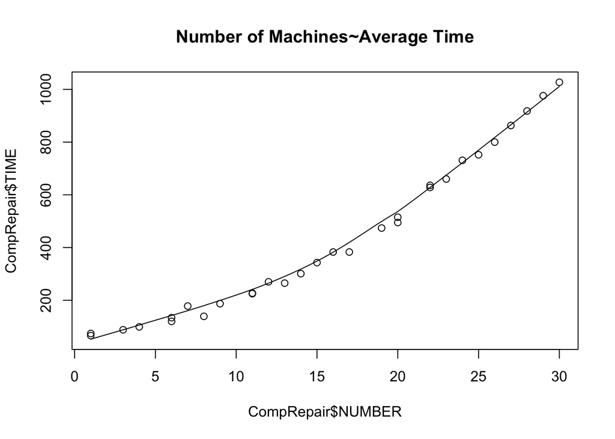

```r
# OR
scatter.smooth(x=CompRepair$NUMBER, y=CompRepair$TIME,
               main="Number of Machines~Average Time")  # scatterplot
```

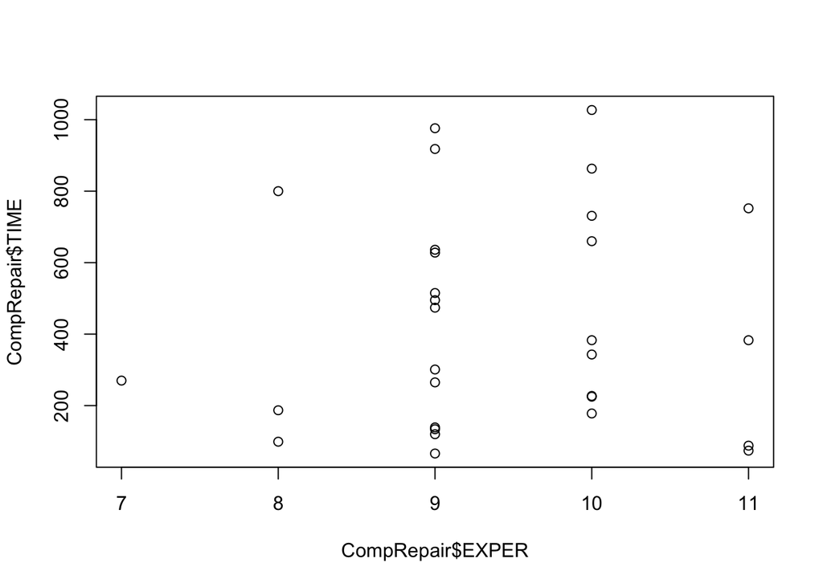

```r
plot(CompRepair$EXPER, CompRepair$TIME)
```

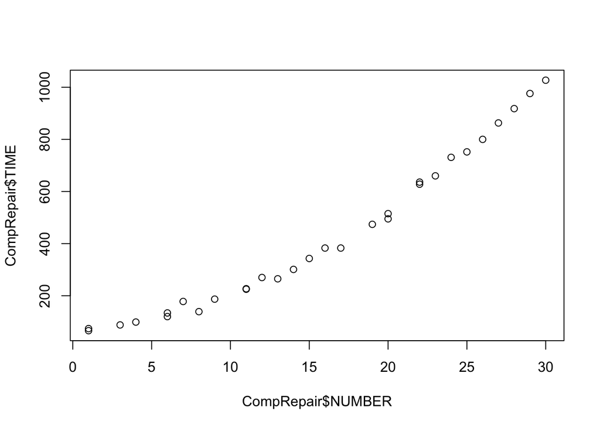

```r
plot(CompRepair$NUMBER, CompRepair$TIME)
```

```r
## Linear model
model1 <- lm(TIME ~ NUMBER + EXPER, data = CompRepair )

## Adding polynomial terms
model2 <- lm(TIME ~ NUMBER + I(NUMBER^2) + EXPER + I(EXPER^2), data = CompRepair )

## Adding interaction term
model3 <- lm(TIME ~ NUMBER + EXPER + NUMBER * EXPER, data = CompRepair )

# Compare models
anova(model1, model2, model3)
```

```
## Analysis of Variance Table
##
## Model 1: TIME ~ NUMBER + EXPER
## Model 2: TIME ~ NUMBER + I(NUMBER^2) + EXPER + I(EXPER^2)
## Model 3: TIME ~ NUMBER + EXPER + NUMBER * EXPER
##   Res.Df    RSS Df Sum of Sq      F                Pr(>F)
## 1     27 126365
## 2     25   5641  2    120724 267.53 < 0.00000000000000022 ***
## 3     26 123994 -1   -118353 524.56 < 0.00000000000000022 ***
## ---
## Signif. codes:  0 '***' 0.001 '**' 0.01 '*' 0.05 '.' 0.1 ' ' 1
```

```r
print("Model 2, with an RRS of 5641, exhibits a significantly lower RRS compared to Model 1, which has an RRS of 126365. Additionally, the P-value of Model 2 is less than 0.05 (< 2.2e-16), indicating its statistical significance. While Model 3 also has a P-value under 0.05, the presence of negative degrees of freedom and a negative Sum of Squares in the comparison with Model 2 might point to a potential misinterpretation of the ANOVA table or a problem with how the model is specified. Based on these observations from the ANOVA table, Model 2 (quadratic model) seems to be the preferable choice.")
```

[output not shown]